# baroth_OriginalHomeworkCode_05

Brooke Rothamer

2023-11-18

## Peer Commentary:

1. What you learned from running their Original Homework Code that helped improve your own code.
- I loved the way that you included histograms of the coefficient distributions! I’m a visual learner, so I loved seeing a visual of your work.
2. What you did in your own code that might help to improve theirs.
- I added a way to easily call the confidence intervals, rather than doing it manually.
3. What challenges, if any, you both faced in your code that could not be helped by comparison.
- I think that we both used an incorrect bootstrapping method at first, so the SEs were incorrect. Or, we both tried to get the SEs incorrectly because mine looked the same as yours before I did a different method. If you use the website I listed below, I think it will get the correct SEs for the bootstrapping method. Overall, I am happy that this homework was short as I am sure you are happy about too!!
4. Whether the annotation/commenting on your peer’s Original Homework Code is readable and interpretable to you, and if not then how it could be improved.
- Your code is readable and interpretable! Your descriptions are clear and the way you walk through everything you are doing is great. Great job. It knitted perfectly and looks great.

# Homework 5: Bootstrapping Standard Errors and CIs for Linear Models.

When we initially discussed the central limit theorem and confidence intervals, we showed how we could use bootstrapping to estimate standard errors and confidence intervals around certain parameter values, like the mean. Using bootstrapping, we could also do the same for estimating standard errors and CIs around regression parameters, such as β coefficients.

Peer Commentary: I like your description above! -Lillian

## Linear Regression

Using the “KamilarAndCooperData.csv” dataset, run a linear regression looking at log(HomeRange_km2) in relation to log(Body_mass_female_mean) and report your β coeffiecients (slope and intercept).

Load in data.

```r
data <- as.data.frame(read.csv("https://raw.githubusercontent.com/fuzzyatelin/fuzzyatelin.github.io/master/AN588_Fall23/KamilarAndCooperData.csv"))
```

Run linear regression model.

```r
model <- lm(log(data$HomeRange_km2)~log(data$Body_mass_female_mean))
summary(model) #I did it the same way! -Lillian
```

```
##
## Call:
## lm(formula = log(data$HomeRange_km2) ~ log(data$Body_mass_female_mean))
##
## Residuals:
##     Min      1Q  Median      3Q     Max
## -3.3929 -0.9433 -0.0126  1.0944  3.6826
##
## Coefficients:
##                                 Estimate Std. Error t value Pr(>|t|)
## (Intercept)                     -9.44123    0.67293  -14.03   <2e-16 ***
## log(data$Body_mass_female_mean)  1.03643    0.08488   12.21   <2e-16 ***
## ---
## Signif. codes:  0 '***' 0.001 '**' 0.01 '*' 0.05 '.' 0.1 ' ' 1
##
## Residual standard error: 1.423 on 135 degrees of freedom
##   (76 observations deleted due to missingness)
## Multiple R-squared:  0.5248, Adjusted R-squared:  0.5213
## F-statistic: 149.1 on 1 and 135 DF,  p-value: < 2.2e-16
```

```r
model_summary <- summary(model) # pulling out the coefficients this way to facilitate pulling out the standard error later
model_summary$coefficients[,1]
```

```
##                     (Intercept) log(data$Body_mass_female_mean)
##                       -9.441231                        1.036432
```

```r
# You can also do this to find the confidence intervals! You just do ...
confint(model) # added this here, so you can easily get your conf intervals
```

```
##                                       2.5 %    97.5 %
## (Intercept)                     -10.7720889 -8.110374
## log(data$Body_mass_female_mean)   0.8685707  1.204292
```

- β0 = -9.44123
- β1 = 1.03643

## Bootstrapping

Then, use bootstrapping to sample from your data 1000 times with replacement, each time fitting the same model and calculating the same coefficients. This generates a sampling distribution for each β coefficient.

Bootstrapping code adapted from [Medium’s Bootstrap regression in R](https://towardsdatascience.com/bootstrap-regression-in-r-98bfe4ff5007). { I used this website at first - Lillian}

```r
set.seed(42) #setting a seed will give the same sample every time the code is run

sample_coef_beta0 <- NULL # dummy variable to hold 1000 simulated intercepts
sample_coef_beta1 <- NULL # dummy variable to hold 1000 simulated slopes

for (i in 1:1000) { # for i 1 through 1000,
  sample_data = data[sample(1:nrow(data), nrow(data), replace = TRUE), ] #sample data of the same number of rows and columns is drawn from data

  bootstrap_model <- lm(log(sample_data$HomeRange_km2)~log(sample_data$Body_mass_female_mean)) #Run the regression on the sample_data


  sample_coef_beta0 <- c(sample_coef_beta0, bootstrap_model$coefficients[1]) #pull the intercept from each model and saves them in a vector

  sample_coef_beta1 <- c(sample_coef_beta1, bootstrap_model$coefficients[2]) #pull the slope from each model and saves them in a vector
}
```

```r
head(sample_coef_beta0)
```

```
## (Intercept) (Intercept) (Intercept) (Intercept) (Intercept) (Intercept)
##   -8.997325   -8.697628   -8.425565  -10.285687  -10.039812   -9.226301
```

```r
head(sample_coef_beta1)
```

```
## log(sample_data$Body_mass_female_mean) log(sample_data$Body_mass_female_mean)
##                              0.9979428                              0.9291588
## log(sample_data$Body_mass_female_mean) log(sample_data$Body_mass_female_mean)
##                              0.8981052                              1.1298754
## log(sample_data$Body_mass_female_mean) log(sample_data$Body_mass_female_mean)
##                              1.1065845                              1.0196905
```

Peer Commentary: I like how you included historgrams below! I am a visual person, so I love things like this. - Lillian

Quick look at the coefficient distributions.

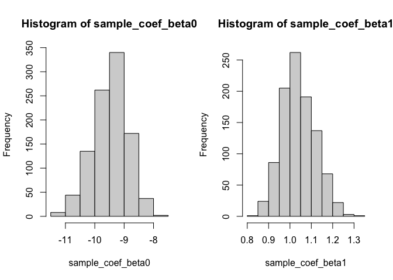

```r
par(mfrow=c(1,2))
hist(sample_coef_beta0)
hist(sample_coef_beta1)
```

## SE and CI of Bootstrapped samples and Comparison

Estimate the standard error for each of your β coefficients as the standard deviation of the sampling distribution from your bootstrap and determine the 95% CI for each of your β coefficients based on the appropriate quantiles from your sampling distribution.

How does the former compare to the SE estimated from your entire dataset using the formula for standard error implemented in lm()?

How does the latter compare to the 95% CI estimated from your entire dataset?

### Standard Errors

SEs from the bootstrap.

```r
sd(sample_coef_beta0)/sqrt(length((sample_coef_beta0))) # standard error of the intercepts
```

```
## [1] 0.01896298
```

```r
sd(sample_coef_beta1)/sqrt(length((sample_coef_beta1))) # standard error of the slopes
```

```
## [1] 0.0024587
```

SEs calculated from the entire dataset.

```r
model_summary$coefficients[,2]
```

```
##                     (Intercept) log(data$Body_mass_female_mean)
##                      0.67293459                      0.08487709
```

The SEs from the entire dataset differ from the SEs from the bootstrap by a magnitude of 10, so I am concerned that I did something wrong.

Peer Commentary: I did this way of bootstrapping at first, but realized that there must be something wrong with how I did it as you realized. This website helped me below to get one that made the SEs and CIS barely differ, so I think it may be the correct way to do it - take a look at the second example:  
https://www.statology.org/bootstrapping-in-r/

-Lillian

### Confidence Intervals

CIs from the bootstrap.

```r
quantile(sample_coef_beta0, c(0.025, 0.975)) #95% confidence interval of the intercepts
```

```
##       2.5%      97.5%
## -10.731968  -8.415115
```

```r
quantile(sample_coef_beta1, c(0.025, 0.975)) #95% confidence interval of the slopes
```

```
##      2.5%     97.5%
## 0.9011129 1.2024555
```

CIs calculated from the entire dataset

```r
confint(model, '(Intercept)', level=0.95)
```

```
##                 2.5 %    97.5 %
## (Intercept) -10.77209 -8.110374
```

```r
confint(model, 'log(data$Body_mass_female_mean)', level=0.95)
```

```
##                                     2.5 %   97.5 %
## log(data$Body_mass_female_mean) 0.8685707 1.204292
```

Peer Commentary: Yeah, the way you found your CIs appears to work – nice job! See the website I linked to see if it can help at all with finding the SEs. It made it so my SEs were similar just as the CIs are! -Lillian